# Template for writing scientific papers in R markdown

## Plots

An example (a pretty ugly one) of a plot is in the code, and visible below (once I get the captioning working again)…Let’s see how this can be improved.

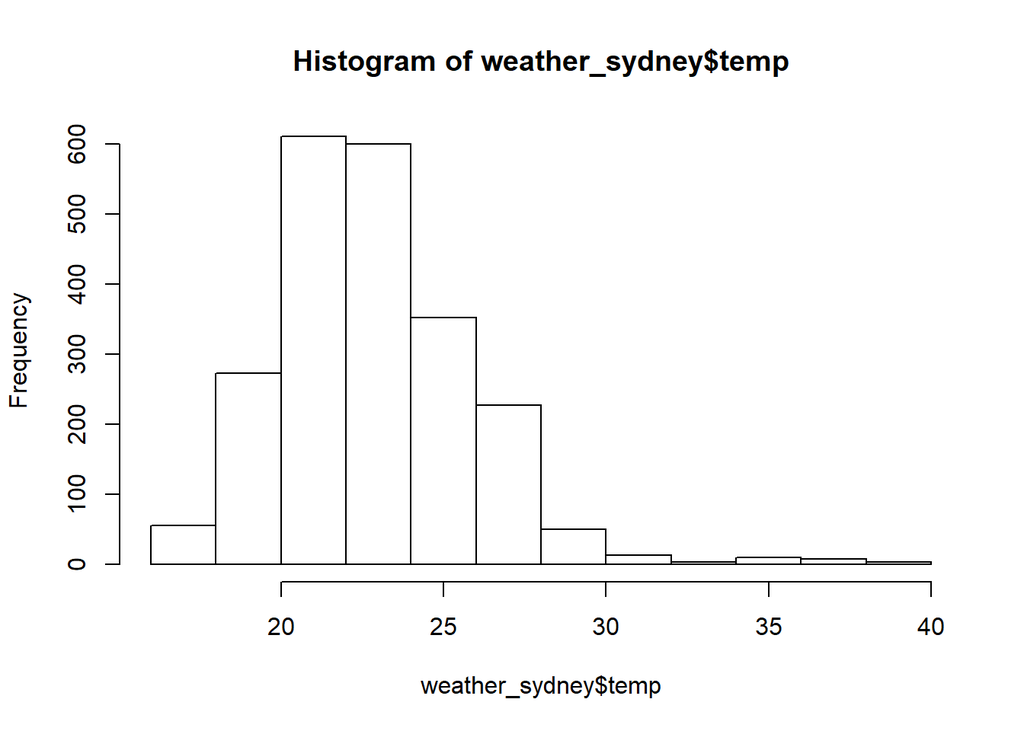

```r
hist(weather_sydney$temp)
```

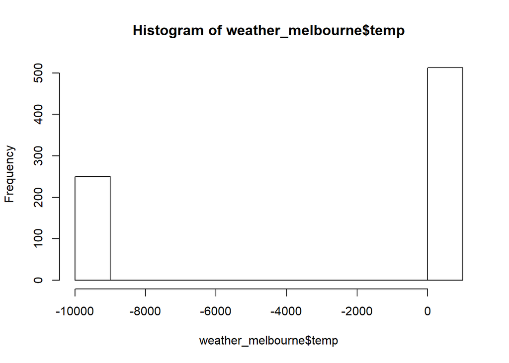

```r
hist(weather_melbourne$temp)
```

```r
#this data used to need a lot more cleaning! Previously, you need to remove -9999 values
SYD_temp <- as.data.frame(as.numeric(unlist(subset(weather_sydney, temp >-300, select=c("temp"))))) #you could also replace these wiht NA, but here we're just going to exclude the missing data
colnames(SYD_temp)[1] <- "temp"
SYD_temp$loc <- "SYD"

MEL_temp <- as.data.frame(as.numeric(unlist(subset(weather_melbourne, temp >-300, select=c("temp")))))
colnames(MEL_temp)[1] <- "temp"
MEL_temp$loc <- "MEL"

temps <- rbind(SYD_temp, MEL_temp)
temps$temp <- as.numeric(temps$temp)
```

First off, I did a bit of cleaning (code chunk above). The ggplot package makes much nicer figures, like that shown in 1, *but* what’s wrong with that figure?

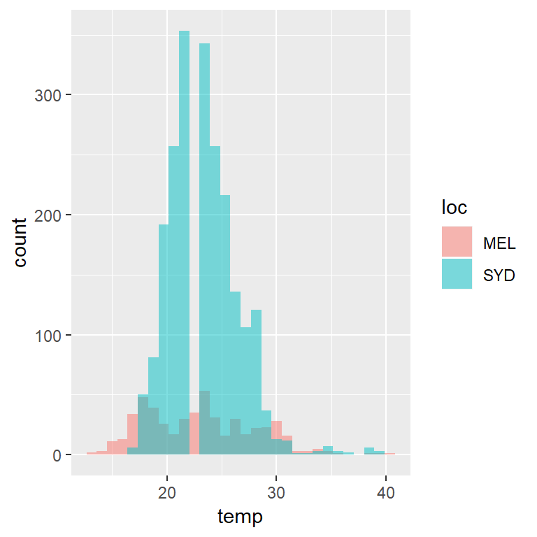

pretty histograms

```r
ggplot(temps, aes(x = temp, fill = loc)) + geom_histogram(alpha = .5, position = 'identity')
```

Hm, ok let’s try and fix 1 …

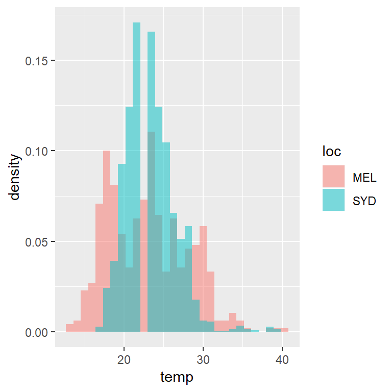

pretty histograms

```r
ggplot(temps, aes(x = temp, fill = loc)) + geom_histogram(alpha = .5, aes(y = ..density..), position = 'identity') #note use of 'density' because we have unequal temperature counts in each dataset, and this lets us understand the data as a percentage over the period. Alpha is the transparency level.
```

2 is an improvement. There’s another (also simple) way to do this

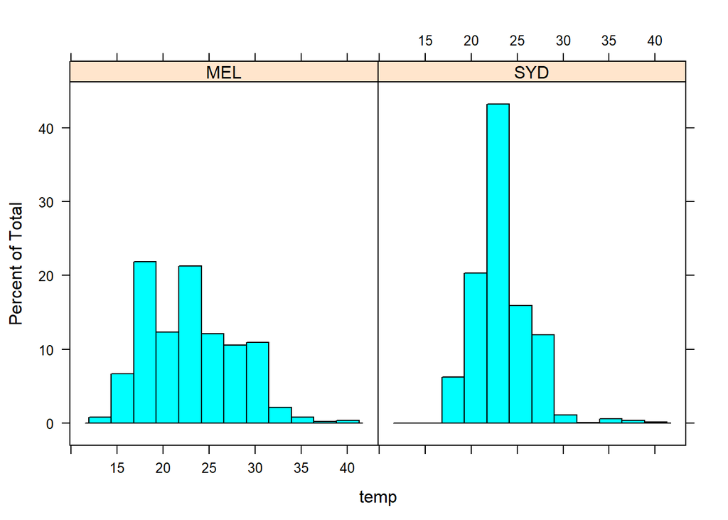

```r
histogram(~ temp | loc, data=temps)
```

What’s wrong with this?

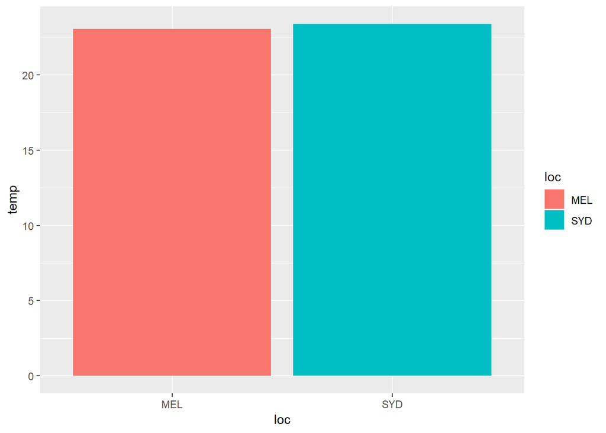

```r
ggplot(temps) +
  geom_bar(aes(x = loc, y = temp, fill = loc),
           position = "dodge", stat = "summary", fun.y = "mean")
```

More informative?

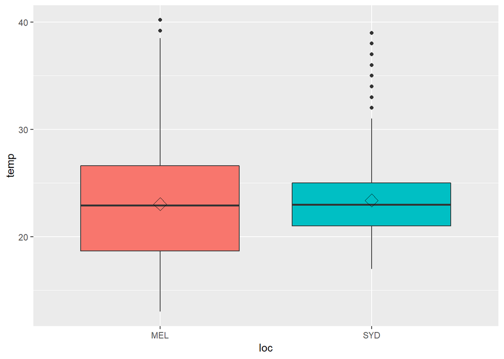

```r
ggplot(temps, aes(x=loc, y=temp, fill=loc)) + geom_boxplot() +
    guides(fill=FALSE)+
    stat_summary(fun.y=mean, geom="point", shape=5, size=4)
```

Couple of useful things - let’s pull the date out to its own value, and this time we’ll replace missing values (-9999) with NA

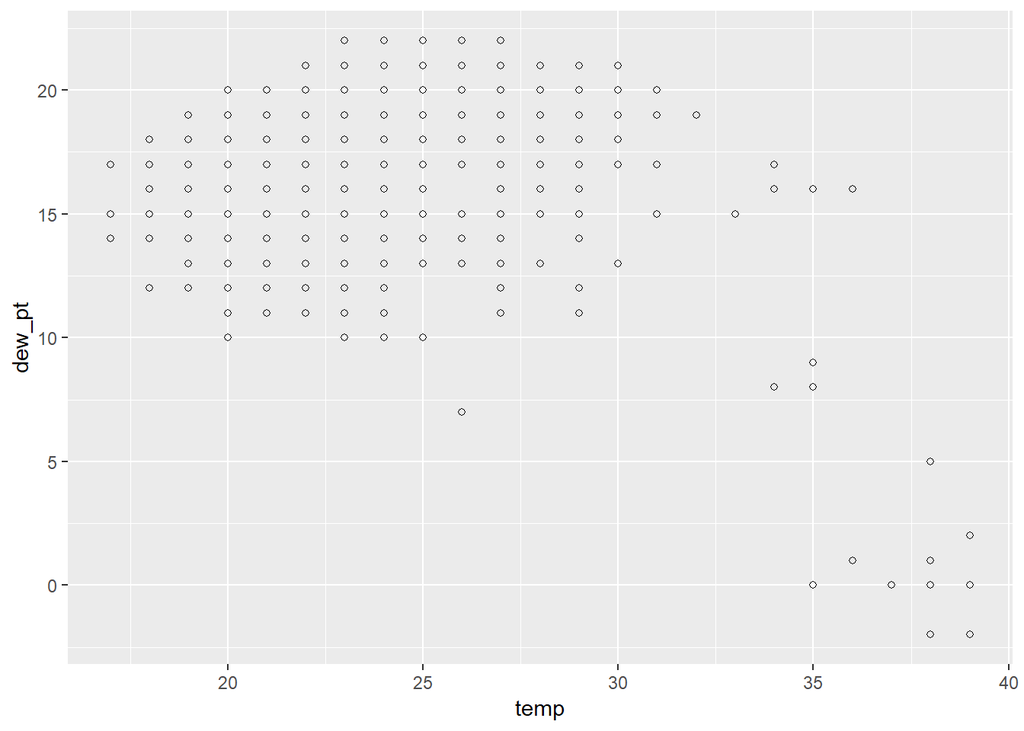

```r
ggplot(weather_sydney, aes(x=temp, y=dew_pt)) +
    geom_point(shape=1)      # Use hollow circles
```

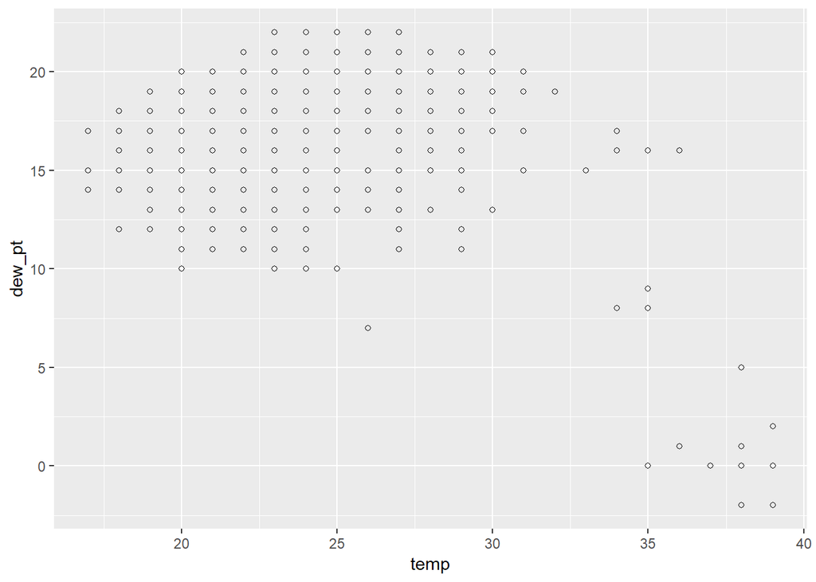

```r
weather_sydney[weather_sydney == -9999] <- NA
weather_sydney$date <- as.Date(weather_sydney$date)

weather_melbourne[weather_melbourne == -9999] <- NA
weather_melbourne$date <- as.Date(weather_melbourne$date)

ggplot(weather_sydney, aes(x=temp, y=dew_pt)) +
    geom_point(shape=1)      # Use hollow circles
```

What if we want to explore the relationship between dew_pt and other features https://support.office.com/en-us/article/Present-your-data-in-a-scatter-chart-or-a-line-chart-4570a80f-599a-4d6b-a155-104a9018b86e

One way you might be tempted to do this…

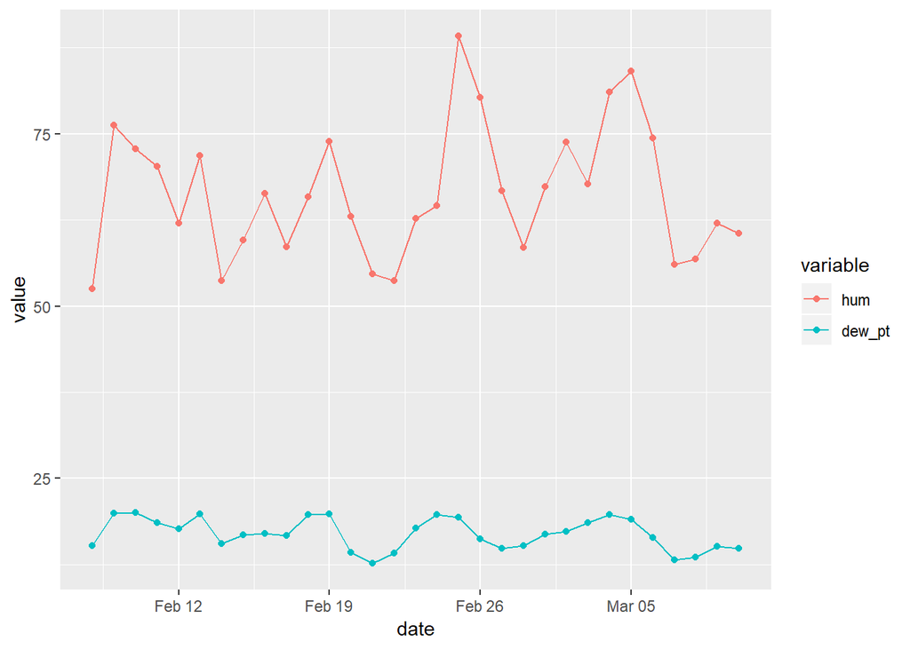

```r
bad_example <- subset(weather_sydney, !is.na(hum), select=c("hum", "dew_pt","date"))
bad_example[c("hum","dew_pt")] <- lapply(bad_example[c("hum","dew_pt")],as.numeric)

bad_example <- aggregate(. ~ date, bad_example, FUN=mean)

#convert to long
bad_example <- melt(bad_example, id.vars = c("date"))

ggplot(data=bad_example, aes(x=date, y=value, group=variable, colour=variable)) +
    geom_line() +
    geom_point()
```

```r
#Is date an important variable in this analysis? Does the scaling of the data gives us the best available insight into relationships of paired values? Is the use of a line to join datapoints appropriate given missing data?
```

A better way?

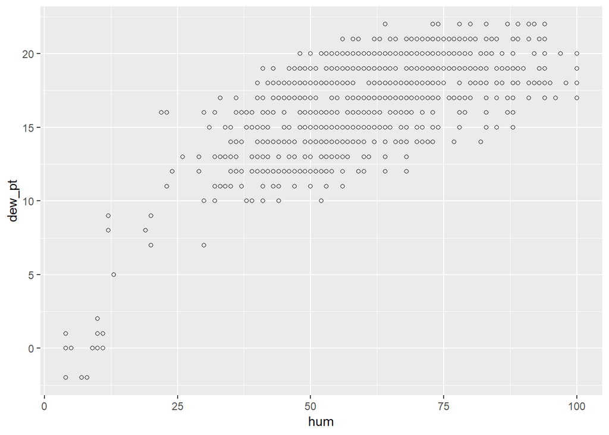

```r
ggplot(weather_sydney, aes(x=hum, y=dew_pt)) +
    geom_point(shape=1)      # Use hollow circles
```

```r
cor.test(as.numeric(weather_sydney$hum),as.numeric(weather_sydney$dew_pt))
```

```
##
##  Pearson's product-moment correlation
##
## data:  as.numeric(weather_sydney$hum) and as.numeric(weather_sydney$dew_pt)
## t = 40.31, df = 2204, p-value < 2.2e-16
## alternative hypothesis: true correlation is not equal to 0
## 95 percent confidence interval:
##  0.6267465 0.6748281
## sample estimates:
##       cor
## 0.6514409
```

Of course, you don’t have to just display the correlation, you can ***output the coefficient in-line with code: 0.6514409**

Ok what if we want to look at how weather varies over time and place?

```r
weather_sydney$loc <- "Sydney"
weather_melbourne$loc <- "Melbourne"
```

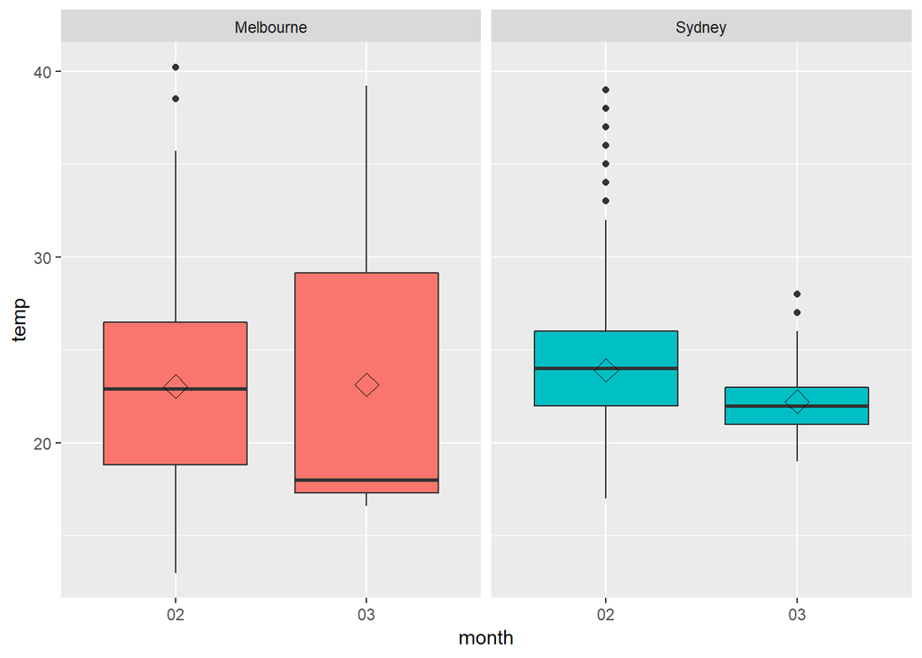

```r
weather <- rbind(weather_sydney[c("temp","dew_pt","hum","wind_spd","precip_total","cond","date","loc")],weather_melbourne[c("temp","dew_pt","hum","wind_spd","precip_total","cond","date","loc")])
weather$month <- format(as.Date(weather$date), "%m")

ggplot(weather, aes(x=month, y=temp, fill=loc)) + geom_boxplot() +
    guides(fill=FALSE) +
    stat_summary(fun.y=mean, geom="point", shape=5, size=4) +
    facet_wrap(~loc)
```

Or at how weather events vary by place

```r
#unique(weather$Events)
unique(weather$cond)
```

```
##  [1] "Partly Cloudy"                "Clear"
##  [3] ""                             "Mostly Cloudy"
##  [5] "Scattered Clouds"             "Haze"
##  [7] "Thunderstorm"                 "Light Rain Showers"
##  [9] "Light Thunderstorms and Rain" "Light Rain"
## [11] "Overcast"                     "Unknown"
## [13] "Rain Showers"                 "Light Drizzle"
## [15] "Drizzle"                      "Heavy Rain Showers"
## [17] "Rain"                         NA
```

```r
table(weather$cond,weather$loc)
```

```
##
##                                Melbourne Sydney
##                                        0    470
##   Clear                                0    285
##   Drizzle                              0      3
##   Haze                                 0     63
##   Heavy Rain Showers                   0      2
##   Light Drizzle                        0     11
##   Light Rain                           0     40
##   Light Rain Showers                   0     72
##   Light Thunderstorms and Rain         0      5
##   Mostly Cloudy                        0    591
##   Overcast                             0     27
##   Partly Cloudy                        0    362
##   Rain                                 0     10
##   Rain Showers                         0     13
##   Scattered Clouds                     0    247
##   Thunderstorm                         0      1
##   Unknown                              0      4
```

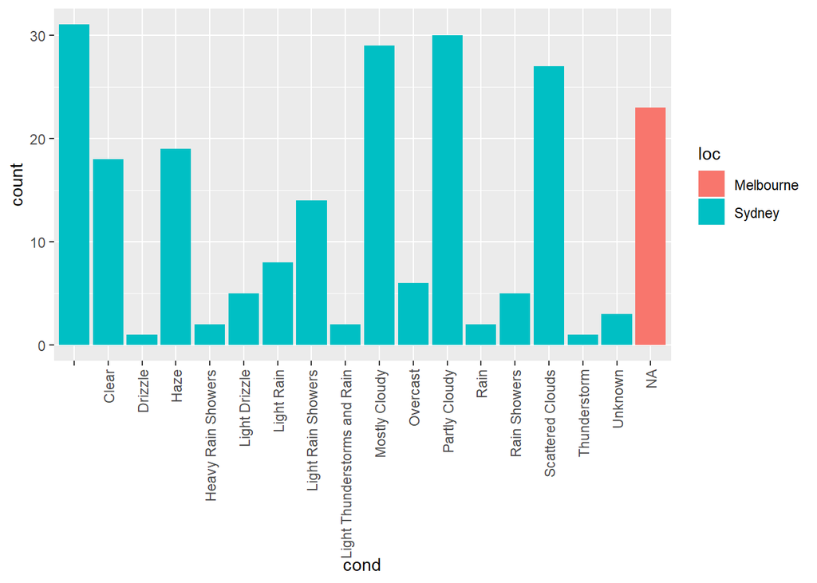

```r
weather_con <- unique(subset(weather,select=c("cond","date","loc")))

ggplot(data=weather_con, aes(x=cond, fill = loc)) +
    geom_bar(position=position_dodge()) +
    theme(axis.text.x = element_text(angle = 90, vjust = .5, hjust = 1))
```

```r
#weather_con <- unique(subset(weather,select=c("Events","DateUTC","loc")))
#ggplot(data=weather_con, aes(x=Events, fill = loc)) +
 #   geom_bar(position=position_dodge()) +
    #scale_y_continuous(labels=scales::percent) +
  #  theme(axis.text.x = element_text(angle = 90, vjust = .5, hjust = 1))
```

We’ve often seen students refer to ‘average mood’. Sometimes this might make sense, but this is an analogous example…

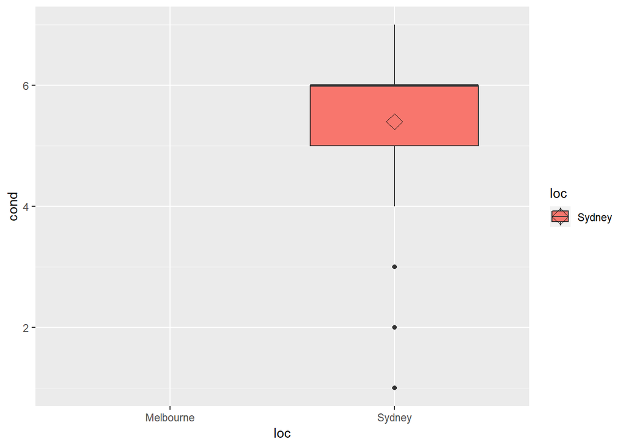

```r
#let's take the weather event data, and code it from best ('no event') to worst ('snow')
weather_con$cond[weather_con$cond=="Clear"] <- 7
weather_con$cond[weather_con$cond==""] <- 6
weather_con$cond[weather_con$cond=="Mostly Cloudy"] <- 5
weather_con$cond[weather_con$cond=="Light Rain Showers"] <- 4
weather_con$cond[weather_con$cond=="Light Thunderstorms and Rain"] <- 3
weather_con$cond[weather_con$cond=="Heavy Rain Showers"] <- 2
weather_con$cond[weather_con$cond=="Thunderstorm"] <- 1

weather_con$cond <- as.numeric(weather_con$cond)

ggplot(weather_con, aes(x = loc, y = cond, fill=loc)) + geom_boxplot() +
    stat_summary(fun.y=mean, geom="point", shape=5, size=4)
```

# Findings and Conclusions

# Discussion

Your ‘justification’ and evaluation of your approach is likely to go in this section, but may also be threaded through the preceding sections. This includes Criterion 3: Identifies, contextualises, and reflects on the ethical, privacy, and legal issues relevant to the collection and analysis of personal data of self and others. >

# Reflection

# Other

If you are submitting any additional materials, such as short multimedia presentations or visualisations (such as Prezi, or voice-over video/screen capture, etc), they probably can’t be submitted through UTSOnline so you will need to arrange some other process such as posting on YouTube or elsewhere, or handing in a memory stick or CD/DVD. Please ensure that additional material like this is accessible to the markers (test this by accessing it through someone else’s computer) and avoid any restrictive or proprietary software constraints. Remember to check any inculded web links!

Diagrams, figures, charts and illustrations must be labelled, and explained, and must be referred to from somewhere in the report. If drawn from another source, then the source must be provided.

# References

```r
  write.bibtex(file="references.bib")
```

Boettiger, C. (2017). *Knitcitations: Citations for ’knitr’ markdown files*. Retrieved from https://CRAN.R-project.org/package=knitcitations

Halpern, B.S., Regan, H.M., Possingham, H.P. & McCarthy, M.A. (2006). Accounting for uncertainty in marine reserve design. *Ecology Letters*, **9**, 2–11. Retrieved from https://doi.org/10.1111/j.1461-0248.2005.00827.x

Keil, P., Belmaker, J., Wilson, A.M., Unitt, P. & Jetz, W. (2012). Downscaling of species distribution models: a hierarchical approach (R. Freckleton, Ed.). *Methods in Ecology and Evolution*, **4**, 82–94. Retrieved from https://doi.org/10.1111/j.2041-210x.2012.00264.x

R Core Team. (2018). *R: A language and environment for statistical computing*. R Foundation for Statistical Computing, Vienna, Austria. Retrieved from https://www.R-project.org/

Unknown. (2019). Unknown. Retrieved from https://theconversation.com/artificial-intelligence-holds-great-potential-for-both-students-and-teachers-but-only-if-used-wisely-81024

[^1]: This is a footnote, see how it auto appears at the end of the doc.